# Visualización de Texto

Ramiro Casó - Incae Business School

3/29/2021

## Visualicemos la data de texto que tenemos.

En la primera parte de estos breves tutoriales / repasos, analizamos los datos de reviews para el producto Roomba. Hicimos una breve limpieza, tokenizamos, contamos y filtramos palabras (stop words). Ahora podemos empezar a analizar visualmente esa data.

Para ello, necesitaremos el paquete ggplot2.

```r
library(dplyr)
```

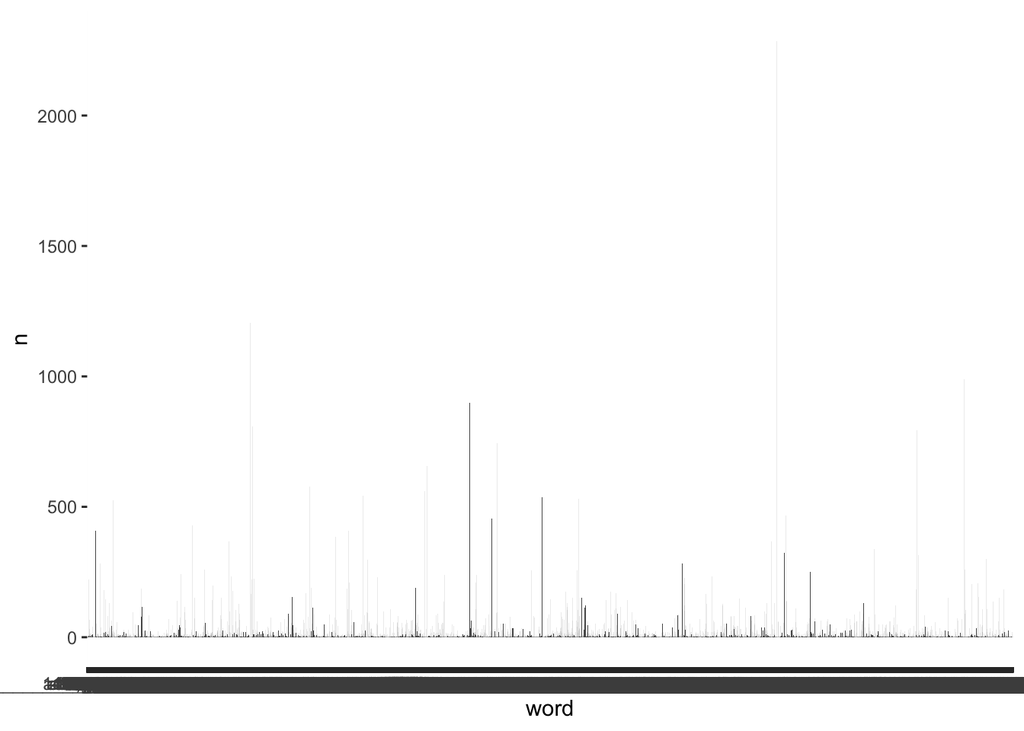

```r
library(ggplot2)
library(tidytext)
library(readr)
library(forcats)

review_data <- read_csv("Roomba Reviews.csv")
tidy_review <- review_data %>%
  unnest_tokens(word, Review) %>%
  anti_join(stop_words)
word_counts <- tidy_review %>%
  count(word)  %>%
  arrange(desc(n))

ggplot(
  word_counts, aes(x = word, y = n)
) + geom_col()
```

Lo que hicemos no da un buen resultado, porque intenta graficar todas las palabras, inclusive las de muy baja frecuencia.

Para resolver este problema, debemos filtrar y dejarnos solo aquellas palabras que tienen una frecuencia alta, de digamos, más de 300.

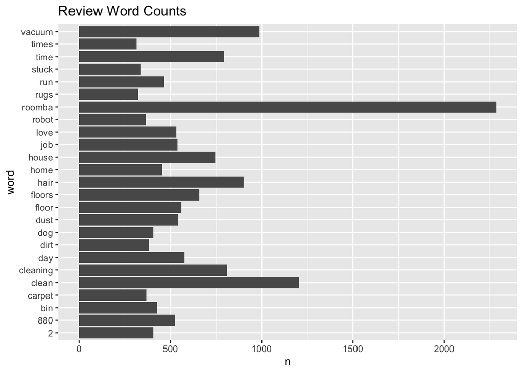

```r
word_count <- tidy_review %>%
  count(word) %>%
  filter (n>300) %>%
  arrange(desc(n))

ggplot(
  word_count, aes(x = word, y = n)
) + geom_col() +
coord_flip() +
  ggtitle("Review Word Counts")
```

## Removiendo custom stop words El siguiente paso es quitar los stops words específicos de este data set y que no están incluídos en el data set de `stopwords` que hemos usado con el `anti-join`.

Para ello, debemos hacer un data frame propio. Podemos hacerlo con el operador `tribble` o armando un data frame normal.

```r
word <- c("roomba","2")
lexicon <- c("CUSTOM", "CUSTOM")
custom_sw <-data.frame(word,lexicon)
custom_sw
```

```
##     word lexicon
## 1 roomba  CUSTOM
## 2      2  CUSTOM
```

Una vez creado ese nuevo data frame, lo debemos unir al que teníamos. Eso lo hacemos con el operador `bind_rows` que le suma filas al data frame original.

```r
stop_words2 <- stop_words %>%
  bind_rows(custom_sw)
```

Ahora repetimos el proceso que hicimos anteriormente, combinando en un solo grupo de código todo lo que necesitamos.

```r
tidy_review2 <- review_data %>%
  mutate(id= row_number()) %>%
  select(id, Date, Product, Stars, Review) %>%
  unnest_tokens(word, Review) %>%
  anti_join (stop_words2)
tidy_review2
```

```
## # A tibble: 76,175 x 5
##       id Date     Product                    Stars word
##    <int> <chr>    <chr>                      <dbl> <chr>
##  1     2 1/12/15  iRobot Roomba 650 for Pets     4 walk
##  2     2 1/12/15  iRobot Roomba 650 for Pets     4 rest
##  3     3 12/26/13 iRobot Roomba 650 for Pets     5 proof
##  4     3 12/26/13 iRobot Roomba 650 for Pets     5 house
##  5     3 12/26/13 iRobot Roomba 650 for Pets     5 awesome
##  6     3 12/26/13 iRobot Roomba 650 for Pets     5 pet
##  7     3 12/26/13 iRobot Roomba 650 for Pets     5 cleans
##  8     4 8/4/13   iRobot Roomba 650 for Pets     3 fascinating
##  9     4 8/4/13   iRobot Roomba 650 for Pets     3 albeit
## 10     4 8/4/13   iRobot Roomba 650 for Pets     3 expensive
## # … with 76,165 more rows
```

Para poder ordenar los gráficos que hemos usado, utilizaremos la función `fct_reorder` que re-ordena las variables de texto.

```r
word_count <- tidy_review2 %>%
  count(word) %>%
  filter (n>300) %>%
  mutate (word2 = fct_reorder(word,n))
word_count
```

```
## # A tibble: 23 x 3
##    word         n word2
##    <chr>    <int> <fct>
##  1 880        525 880
##  2 bin        428 bin
##  3 carpet     368 carpet
##  4 clean     1204 clean
##  5 cleaning   809 cleaning
##  6 day        578 day
##  7 dirt       384 dirt
##  8 dog        407 dog
##  9 dust       543 dust
## 10 floor      561 floor
## # … with 13 more rows
```

Con esto ya podemos hacer el gráfico ordenado.

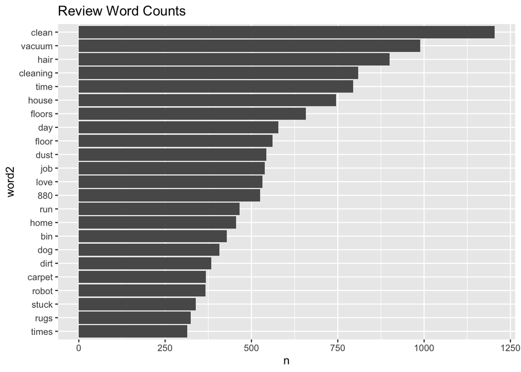

```r
ggplot(
  word_count, aes(x = word2, y = n)
) + geom_col() +
coord_flip() +
  ggtitle("Review Word Counts")
```

## Haciendo nubes de palabras

Yo no soy fan de las nubes de palabras porque me parece que como gráficos son poco explicativos. Pero hay quienes las prefieren, de modo que hay que aprender a hacerlas.

Sería de este modo.

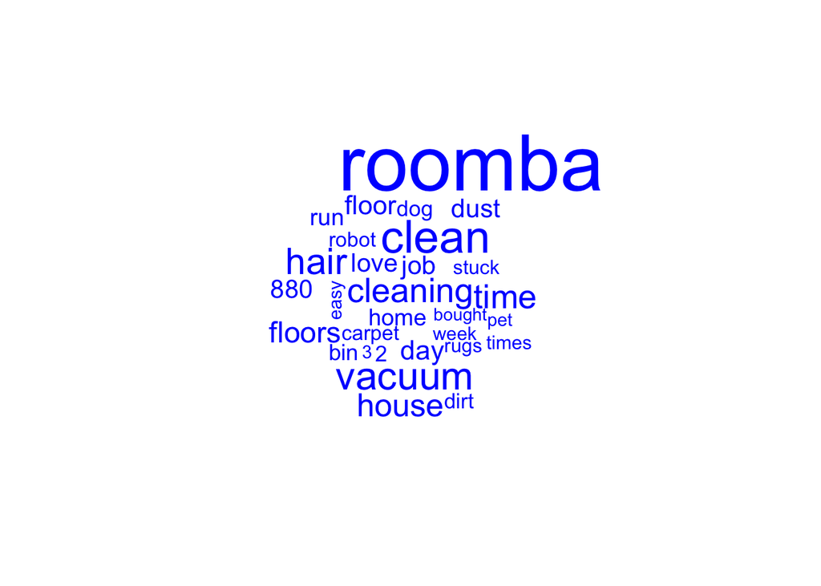

```r
# Cargamos la libreria (previamente instalada) `wordcloud`
library(wordcloud)
# luego usamos nuestro data framde palabras ya limpio: word_counts

word_count <- tidy_review %>%
  count(word)
  wordcloud(
    words = word_count$word,
    freq = word_count$n,
    max.words = 30,
    color = "blue"
  )
```